# NEPA Decarbonization Technology Analysis: Deliverable 6

## Phase Classification Method

Geothermal projects are unique in that a single physical development typically triggers multiple sequential NEPA actions — one for exploration drilling, one or more for production well programs, and a final review for the power plant. This analysis groups geothermal projects by phase and examines timeline patterns by phase.

Phase classification runs in two stages.

**Stage 1 — Regex classifier.** Each NEPA action is scanned against five phase-specific keyword sets applied to concatenated project text (title + description + project type + NOI title + document titles). Assignment logic:

- If **one** phase set matches → that phase is assigned.
- If **two or more** phase sets match → the action is classified as `multi_phase`.
- If **no** phase set matches → the action is classified as `unknown`.

**Stage 2 — ML classifier.** Actions classified as `unknown` by the regex stage are reclassified using a fine-tuned `allenai/scibert_scivocab_uncased` model. The model is trained on the regex-labeled rows with class-weighted loss (to correct for the drilling-heavy imbalance) and a self-training step that expands the effective training set using high-confidence pseudo-labels (threshold 0.70). Input text is title + project type + first 100 words of description, supplemented by up to 300 words of page-level document text where available. At median, the classifier assigns phase labels with approximately 90% softmax confidence.

**Project-level rollup.** After per-action phase assignment, results are collapsed to the project level. A normalized title key is constructed by stripping common geothermal vocabulary (“geothermal”, “well”, “drilling”, “plant”, “project”, etc.) from the project title; actions whose normalized titles match are treated as filings for the same physical development. The **873 NEPA actions** collapse to **753 inferred projects** — a reduction of 120 rows driven by well fields and multi-well programs that generated several sequential CEs or EAs over time. Of these, **753 projects** have a resolved phase (shown in the bar chart below); the remaining 0 could not be classified and are excluded from phase figures.

The table below illustrates the merge with two simplified examples.

Table 2: Simplified examples of how multiple NEPA actions for the same physical geothermal development collapse to a single project row. Normalized key strips common vocabulary; actions that share a key are merged.

| NEPA action (row in data) | Process | Normalized key | Action phase | → Project phase |
| --- | --- | --- | --- | --- |
| Blue Mtn Geothermal Exploration Well Drilling Program | CE | blue mtn | Exploration | Multi-phase |
| Blue Mtn Geothermal Production Well Program | CE | blue mtn | Drilling | ↑ (merged) |
| — | — | — | — | — |
| Ormat Nevada Geothermal Production Well Program Phase I | CE | ormat nevada | Drilling | Drilling |
| Ormat Nevada Geothermal Production Well Program Phase II | CE | ormat nevada | Drilling | ↑ (merged) |

A project is assigned a single phase if all its actions agree; if actions span two or more distinct phases the project is classified as `multi_phase`. **319 projects** are classified as multi-phase. git Table 3 shows representative text cues for each phase.

Table 3: Sample text cues used to classify geothermal development phase. Matching is case-insensitive and uses whole-word boundaries.

| Phase | Sample cues |
| --- | --- |
| Exploration | exploration, exploratory, resource assessment, seismic survey, temperature gradient, feasibility study, slim hole, core hole |
| Drilling | drilling, production well, injection well, well pad, wellfield, well program, well stimulation, wellhead, geothermal well |
| Plant | power plant, binary plant, flash plant, turbine, generating station, power generation, substation, interconnection, steam gathering |
| Operations | steam supply, reinjection, make-up well, makeup well, fluid management, working fluid, geothermal resource utilization |
| Multi-phase | (two or more phase cue sets detected in the same document) |

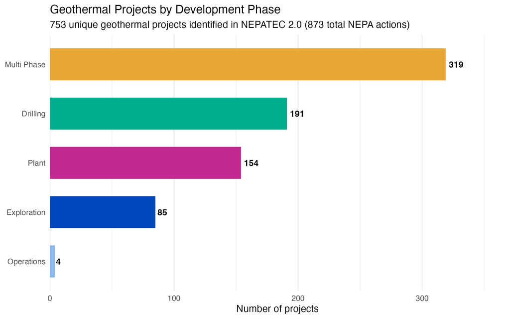

Figure 12: Number of geothermal projects by classified development phase (project-level rollup). Phase is assigned by regex classifier then, for unresolved actions, by a fine-tuned SciBERT ML model; per-action phases are then collapsed to a single project-level label. Projects with no resolved phase (unknown) are excluded.

## Multi-Phase Combinations

Figure 13 shows phase combinations for **241** geothermal projects that span multiple sequential development stages. Each bar shows the count of projects with exactly that combination; filled dots indicate which phases are present. Combinations like Exploration + Drilling reflect the typical progression from resource assessment to well development, while three- and four-phase bars represent projects that advanced through plant construction and operations.

The remaining **78** multi-phase projects (out of **319** total) are excluded. These were classified as multi-phase by the Stage 2 ML classifier: the Stage 1 regex found no strong phase-specific vocabulary match (returning `unknown`), and the ML model inferred from the overall document text that the project spans multiple development stages — but as a single-label classifier, it cannot identify *which* phases are present. Without that information, these projects cannot be placed in a specific combination bar. The 241 shown represent projects where phase assignments were confirmed by the regex pipeline and can be unambiguously attributed to specific development stages.

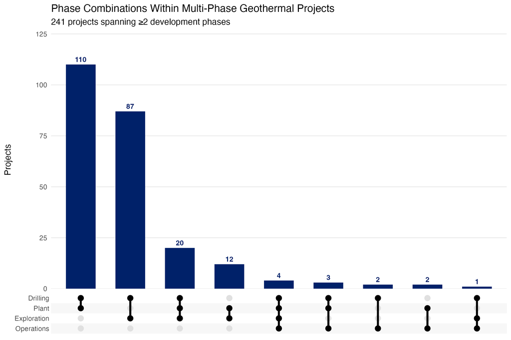

## NEPA Duration by Phase

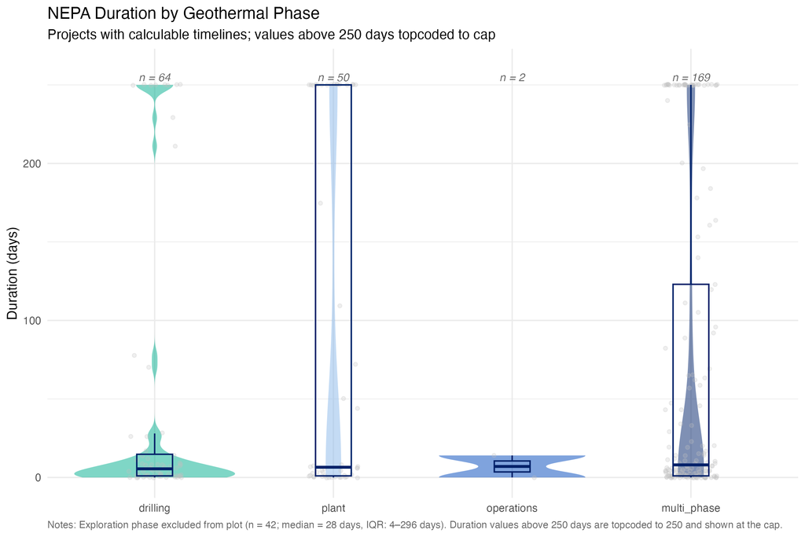

Figure 14: NEPA review duration by geothermal project phase (violin + box). Duration values above 250 days are topcoded to 250 and appear at the cap rather than being dropped. Exploration phase is excluded; see figure footnote for its summary statistics.